# Indian River-Malabar to Vero Beach Aquatic Preserve

SEACAR Water Quality Analysis

Last compiled on 15 July, 2026

# Indicators

## Nutrients

### Total Nitrogen - Discrete

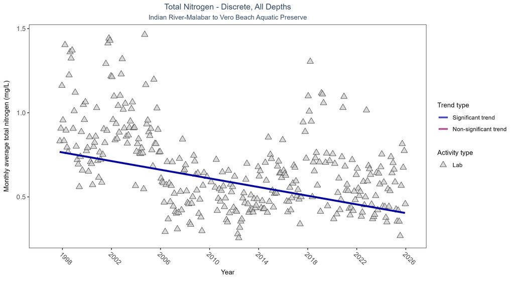

Scatter plot of monthly average total nitrogen over time. If the time series included ten or more years of discrete observations, a significant (blue) or non-significant (magenta) trend line is also shown. Only nitrogen values obtained from laboratory analyses (triangles) are included in the plot.

Table:

Monthly average total nitrogen decreased by 0.01 mg/L per year.

| Activity Type | Statistical Trend | Sample Count | Years with Data | Period of Record | Median Result Value | Tau | Sen Intercept | Sen Slope | P |
| --- | --- | --- | --- | --- | --- | --- | --- | --- | --- |
| Lab | Decreasing trend | 3332 | 29 | 1997 - 2025 | 0.64085 | -0.33234 | 0.77724 | -0.01287 | 0 |

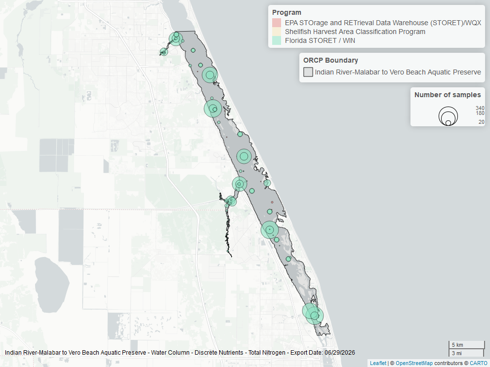

Map showing location of discrete water quality sampling locations within the boundaries of *Indian River-Malabar to Vero Beach Aquatic Preserve*. The bubble size on the maps above reflect the amount of data available at each sampling site.

### Total Phosphorus - Discrete

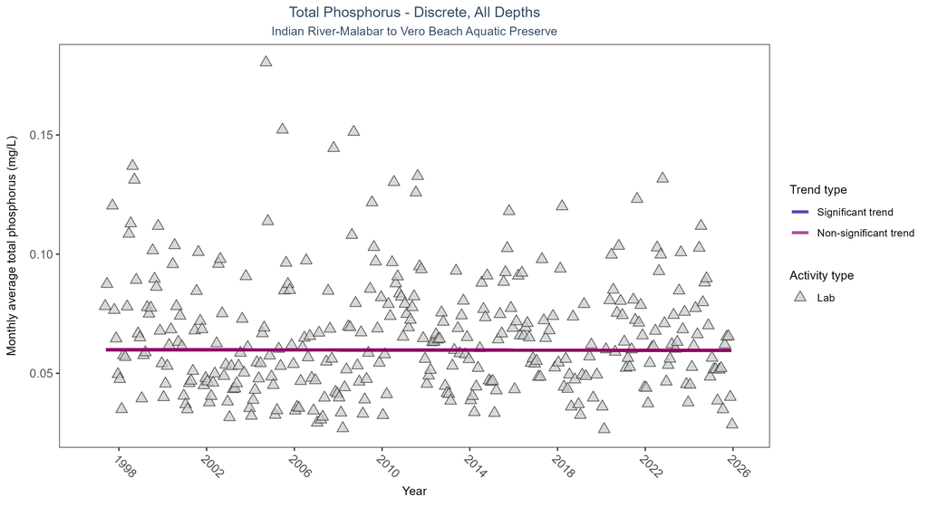

Scatter plot of monthly average total phosphorus over time. If the time series included ten or more years of discrete observations, a significant (blue) or non-significant (magenta) trend line is also shown. Only phosphorus values obtained from laboratory analyses (triangles) are included in the plot.

Table:

Total phosphorus showed no detectable trend between 1997 and 2025.

| Activity Type | Statistical Trend | Sample Count | Years with Data | Period of Record | Median Result Value | Tau | Sen Intercept | Sen Slope | P |
| --- | --- | --- | --- | --- | --- | --- | --- | --- | --- |
| Lab | No detectable trend | 6779 | 29 | 1997 - 2025 | 0.054 | -0.00167 | 0.05989 | -0.00001 | 0.9724 |

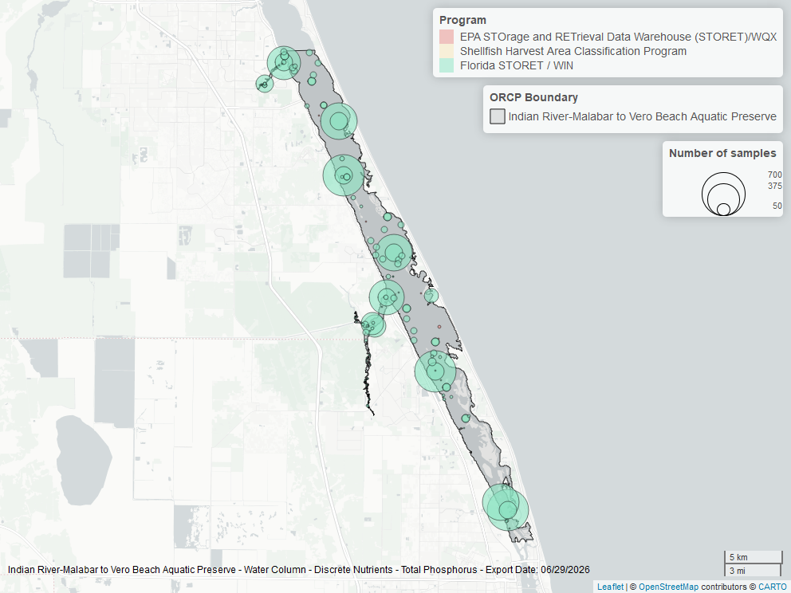

Map showing location of discrete water quality sampling locations within the boundaries of *Indian River-Malabar to Vero Beach Aquatic Preserve*. The bubble size on the maps above reflect the amount of data available at each sampling site.

## Water Quality

### Dissolved Oxygen - Continuous

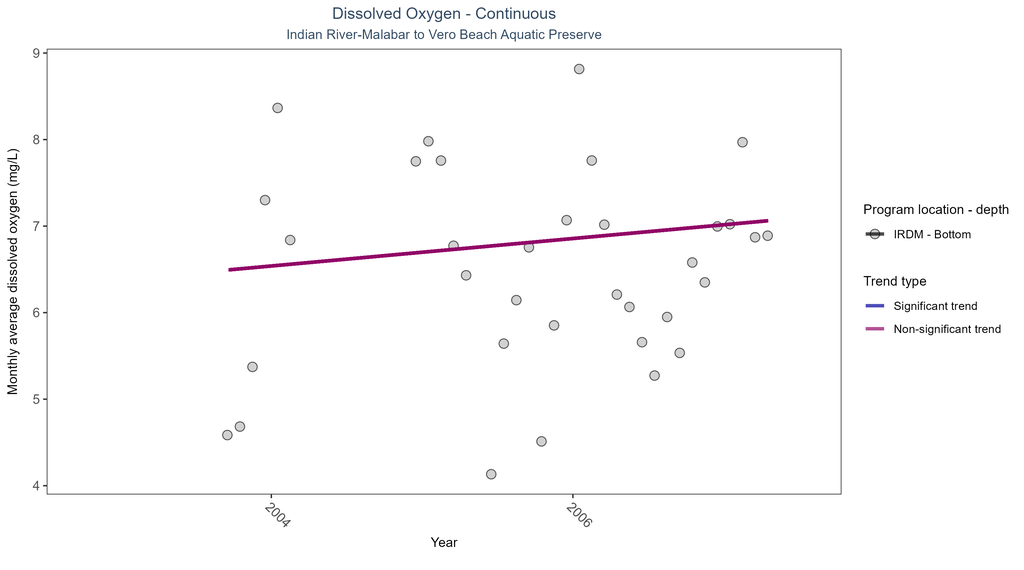

Scatter plot of monthly average dissolved oxygen over time at continuously monitored program locations. Each location is analyzed separately, with significant (blue) or non-significant (magenta) trend lines shown for time series that included five or more years of observations.

Table:

No detectable change in monthly average dissolved oxygen was observed at one location.

| Program Location | Statistical Trend | Sample Count | Years with Data | Period of Record | Median Result Value | Tau | Sen Intercept | Sen Slope | P |
| --- | --- | --- | --- | --- | --- | --- | --- | --- | --- |
| IRDM | No detectable trend | 39746 | 5 | 2003 - 2007 | 6.5 | 0.15 | 6.38 | 0.16 | 0.47 |

[figure not shown]

Map showing location of dissolved oxygen continuous water quality sampling locations within the boundaries of *Indian River-Malabar to Vero Beach Aquatic Preserve*. The bubble size on the maps above reflect the amount of data available at each sampling site.

### Dissolved Oxygen - Discrete

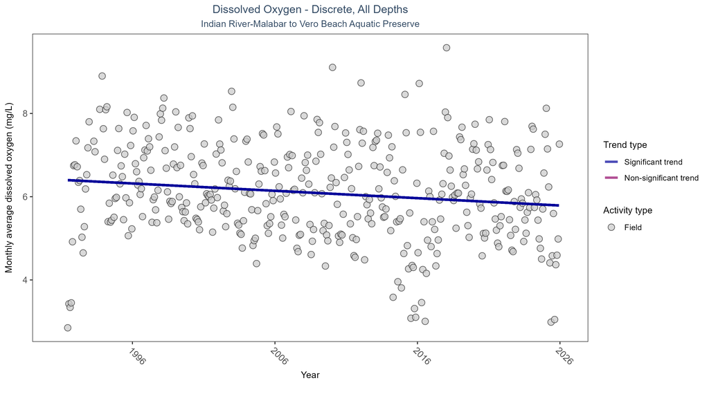

Scatter plot of monthly average dissolved oxygen over time. If the time series included ten or more years of discrete observations, a significant (blue) or non-significant (magenta) trend line is also shown. Only dissolved oxygen values measured in the field (circles) are included in the plot.

Table:

Monthly average dissolved oxygen decreased by 0.02 mg/L per year.

| Activity Type | Statistical Trend | Sample Count | Years with Data | Period of Record | Median Result Value | Tau | Sen Intercept | Sen Slope | P |
| --- | --- | --- | --- | --- | --- | --- | --- | --- | --- |
| Field | Decreasing trend | 58097 | 35 | 1991 - 2025 | 6.2 | -0.16831 | 6.40654 | -0.01766 | 0 |

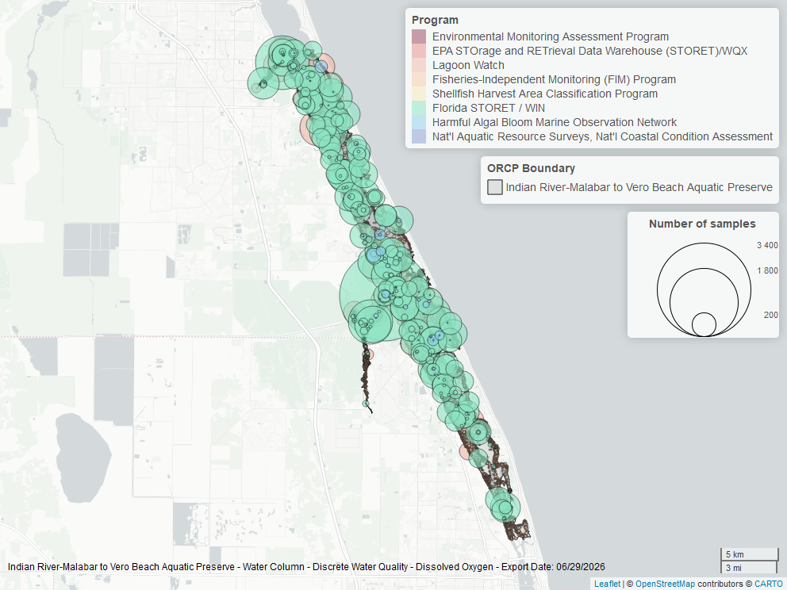

Map showing location of discrete water quality sampling locations within the boundaries of *Indian River-Malabar to Vero Beach Aquatic Preserve*. The bubble size on the maps above reflect the amount of data available at each sampling site.

### Dissolved Oxygen Saturation - Continuous

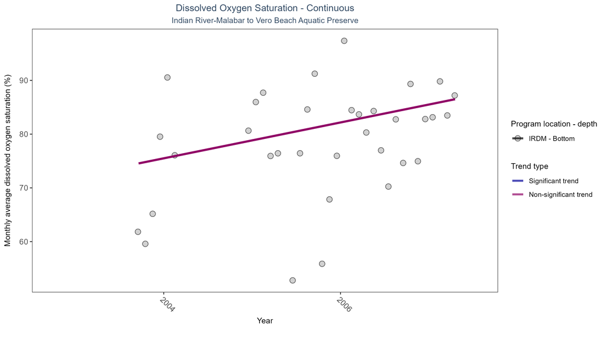

Scatter plot of monthly average dissolved oxygen saturation over time at continuously monitored program locations. Each location is analyzed separately, with significant (blue) or non-significant (magenta) trend lines shown for time series that included five or more years of observations.

Table:

No detectable change in monthly average dissolved oxygen saturation was observed at one location.

| Program Location | Statistical Trend | Sample Count | Years with Data | Period of Record | Median Result Value | Tau | Sen Intercept | Sen Slope | P |
| --- | --- | --- | --- | --- | --- | --- | --- | --- | --- |
| IRDM | No detectable trend | 39746 | 5 | 2003 - 2007 | 77.7 | 0.29 | 72.16 | 3.34 | 0.11 |

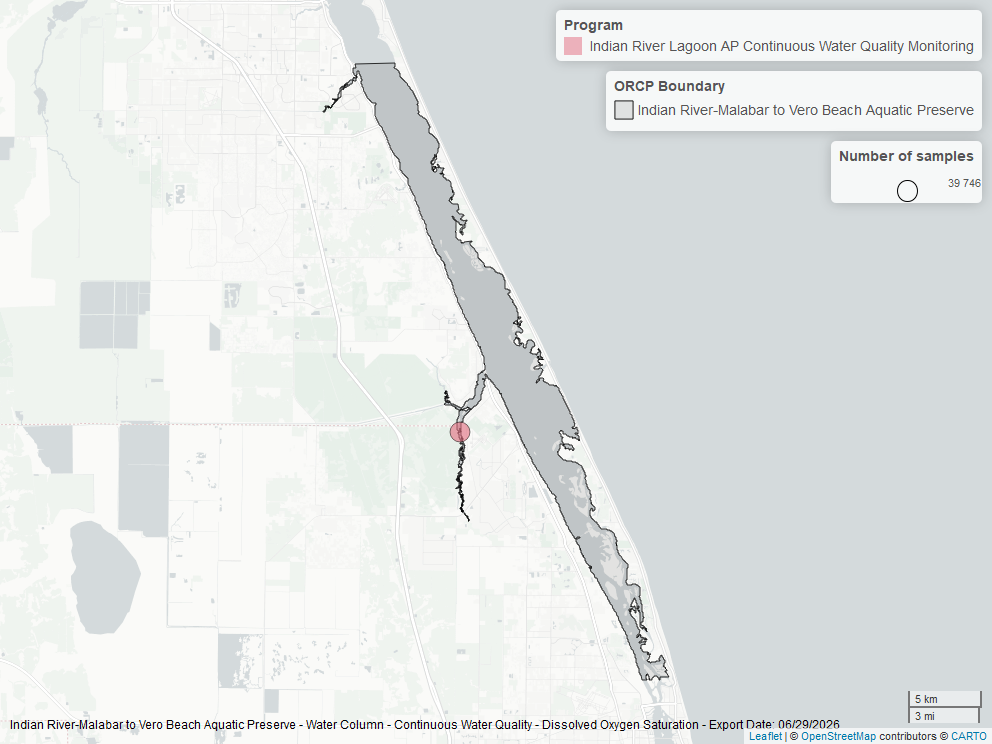

Map showing location of dissolved oxygen saturation continuous water quality sampling locations within the boundaries of *Indian River-Malabar to Vero Beach Aquatic Preserve*. The bubble size on the maps above reflect the amount of data available at each sampling site.

### Dissolved Oxygen Saturation - Discrete

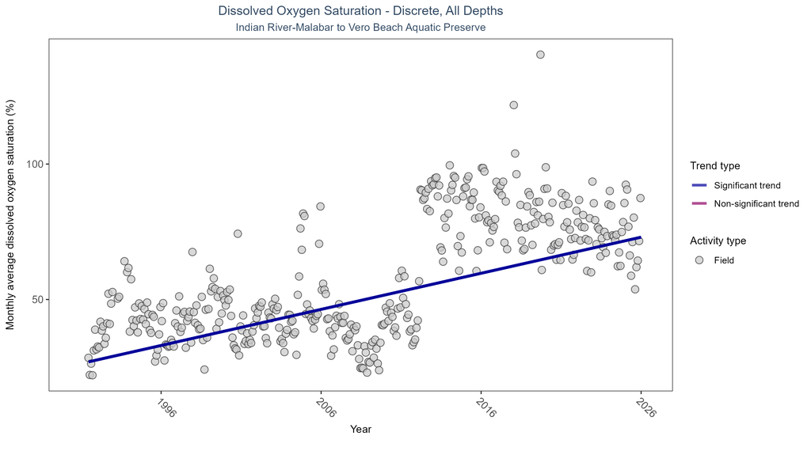

Scatter plot of monthly average dissolved oxygen saturation over time. If the time series included ten or more years of discrete observations, a significant (blue) or non-significant (magenta) trend line is also shown. Only dissolved oxygen saturation values measured in the field (circles) are included in the plot.

Table:

Monthly average dissolved oxygen saturation increased by 1.33% per year.

| Activity Type | Statistical Trend | Sample Count | Years with Data | Period of Record | Median Result Value | Tau | Sen Intercept | Sen Slope | P |
| --- | --- | --- | --- | --- | --- | --- | --- | --- | --- |
| Field | Increasing trend | 13742 | 35 | 1991 - 2025 | 70 | 0.41724 | 26.3719 | 1.33257 | 0 |

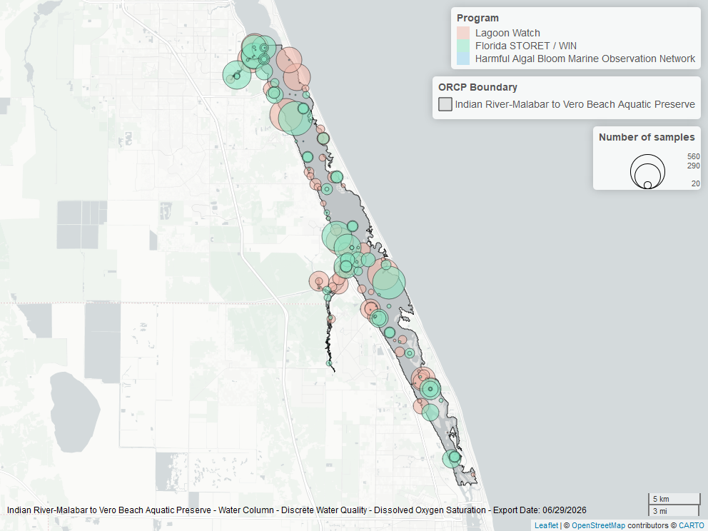

Map showing location of discrete water quality sampling locations within the boundaries of *Indian River-Malabar to Vero Beach Aquatic Preserve*. The bubble size on the maps above reflect the amount of data available at each sampling site.

### Salinity - Discrete

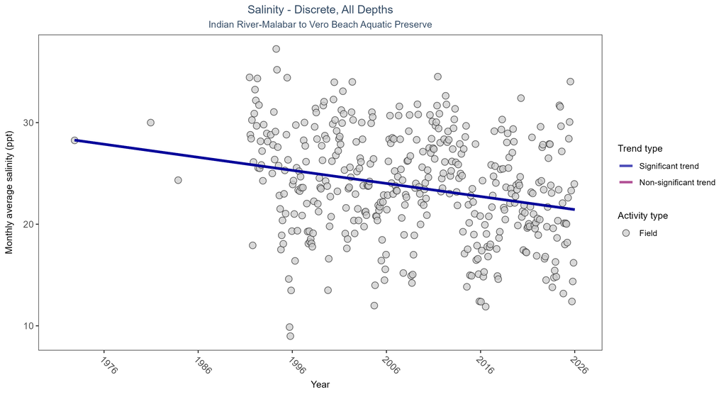

Scatter plot of monthly average salinity over time. If the time series included ten or more years of discrete observations, significant (blue) or non-significant (magenta) trend lines are also shown. Discrete salinity values derived from grab samples analyzed in the field (circles) or the laboratory (triangles) are both included in the plot.

Table:

Monthly average salinity decreased by 0.13 ppt per year.

| Activity Type | Statistical Trend | Sample Count | Years with Data | Period of Record | Median Result Value | Tau | Sen Intercept | Sen Slope | P |
| --- | --- | --- | --- | --- | --- | --- | --- | --- | --- |
| All | Decreasing trend | 61267 | 38 | 1972 - 2025 | 26.1 | -0.19826 | 28.38652 | -0.12865 | 0 |

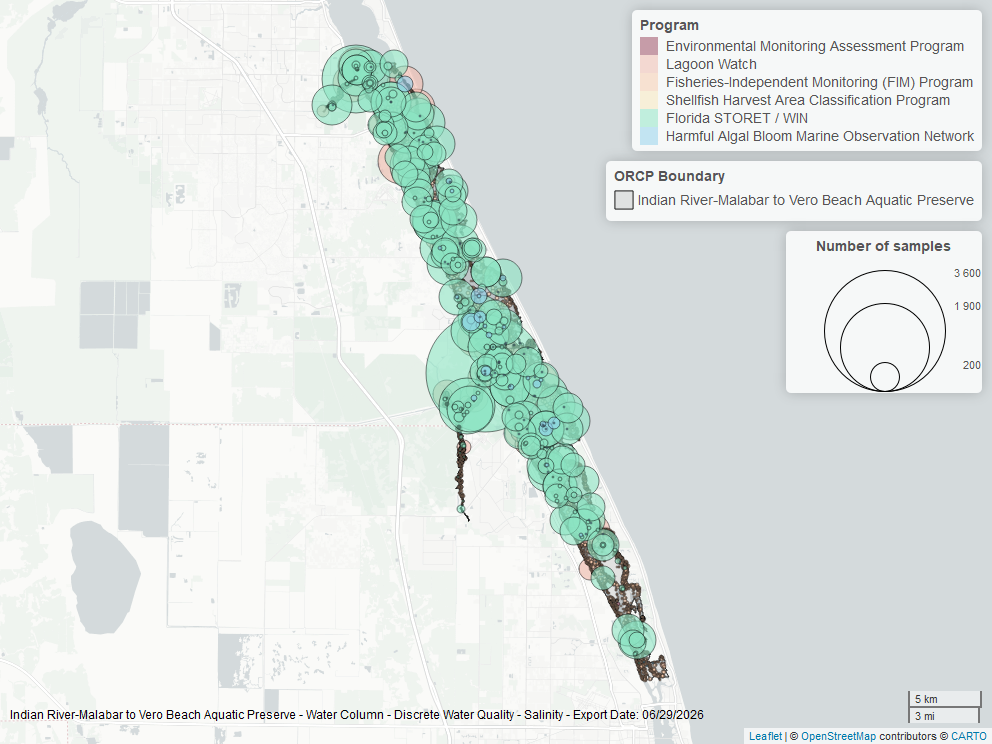

Map showing location of discrete water quality sampling locations within the boundaries of *Indian River-Malabar to Vero Beach Aquatic Preserve*. The bubble size on the maps above reflect the amount of data available at each sampling site.

### Salinity - Continuous

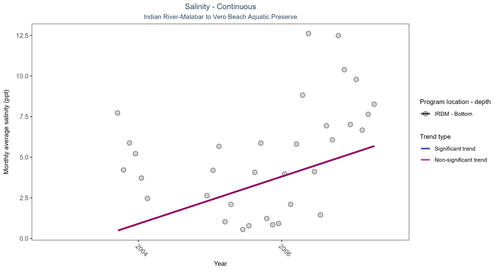

Scatter plot of monthly average salinity over time at continuously monitored program locations. Each location is analyzed separately, with significant (blue) or non-significant (magenta) trend lines shown for time series that included five or more years of observations.

Table:

No detectable change in monthly average salinity was observed at one location.

| Program Location | Statistical Trend | Sample Count | Years with Data | Period of Record | Median Result Value | Tau | Sen Intercept | Sen Slope | P |
| --- | --- | --- | --- | --- | --- | --- | --- | --- | --- |
| IRDM | No detectable trend | 43791 | 5 | 2003 - 2007 | 3.9 | 0.45 | -0.55 | 1.45 | 0.06 |

[figure not shown]

Map showing location of salinity continuous water quality sampling locations within the boundaries of *Indian River-Malabar to Vero Beach Aquatic Preserve*. The bubble size on the maps above reflect the amount of data available at each sampling site.

### Water Temperature - Continuous

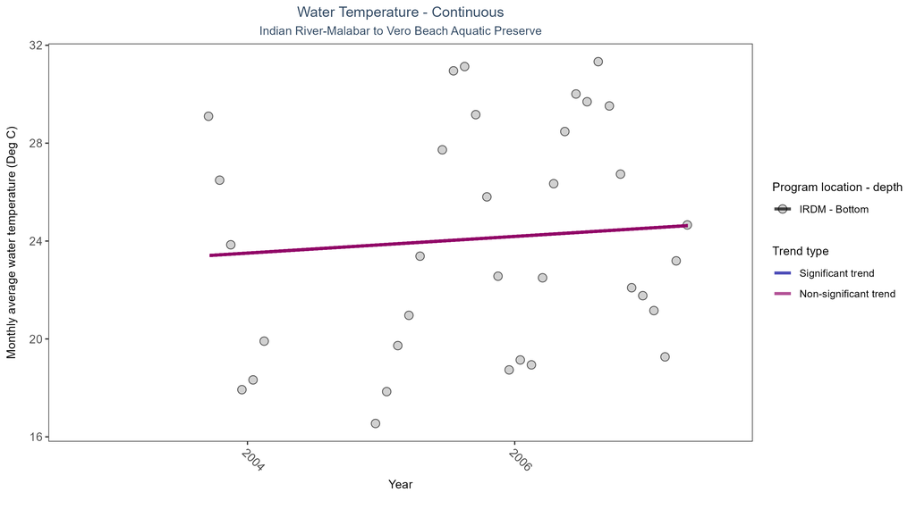

Scatter plot of monthly average water temperature over time at continuously monitored program locations. Each location is analyzed separately, with significant (blue) or non-significant (magenta) trend lines shown for time series that included five or more years of observations.

Table:

No detectable change in monthly average water temperature was observed at one location.

| Program Location | Statistical Trend | Sample Count | Years with Data | Period of Record | Median Result Value | Tau | Sen Intercept | Sen Slope | P |
| --- | --- | --- | --- | --- | --- | --- | --- | --- | --- |
| IRDM | No detectable trend | 43791 | 5 | 2003 - 2007 | 23.5 | 0.29 | 23.17 | 0.34 | 0.19 |

[figure not shown]

Map showing location of water temperature continuous water quality sampling locations within the boundaries of *Indian River-Malabar to Vero Beach Aquatic Preserve*. The bubble size on the maps above reflect the amount of data available at each sampling site.

### Water Temperature - Discrete

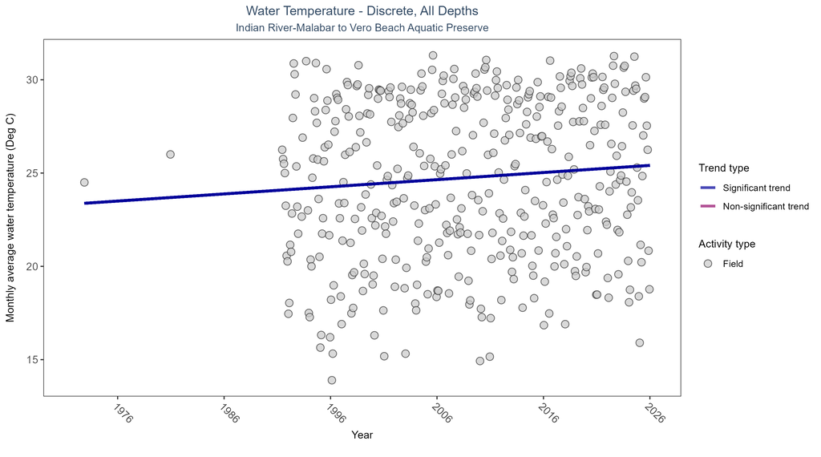

Scatter plot of monthly average water temperature over time. If the time series included ten or more years of discrete observations, a significant (blue) or non-significant (magenta) trend line is also shown. Only water temperature measurements taken in the field (circles) are included in the plot.

Table:

Monthly average water temperature increased by 0.04°C per year.

| Activity Type | Statistical Trend | Sample Count | Years with Data | Period of Record | Median Result Value | Tau | Sen Intercept | Sen Slope | P |
| --- | --- | --- | --- | --- | --- | --- | --- | --- | --- |
| Field | Increasing trend | 60387 | 37 | 1972 - 2025 | 25.5 | 0.21124 | 23.3464 | 0.03824 | 0 |

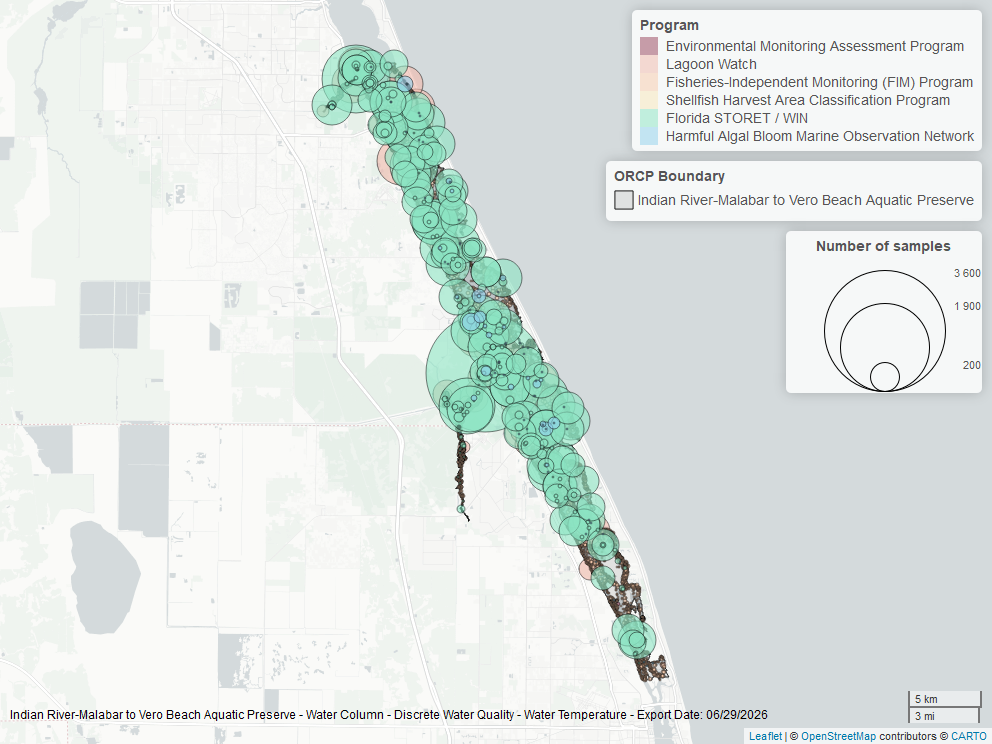

Map showing location of discrete water quality sampling locations within the boundaries of *Indian River-Malabar to Vero Beach Aquatic Preserve*. The bubble size on the maps above reflect the amount of data available at each sampling site.

### pH - Continuous

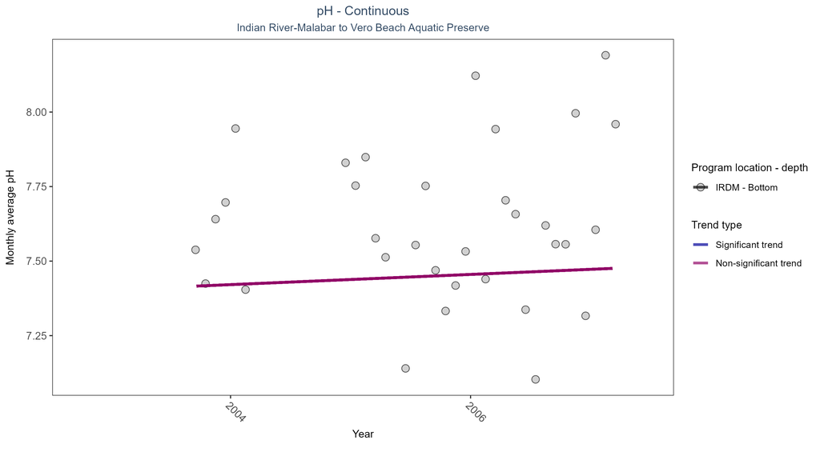

Scatter plot of monthly average pH over time at continuously monitored program locations. Each location is analyzed separately, with significant (blue) or non-significant (magenta) trend lines shown for time series that included five or more years of observations.

Table:

No detectable change in monthly average pH was observed at one location.

| Program Location | Statistical Trend | Sample Count | Years with Data | Period of Record | Median Result Value | Tau | Sen Intercept | Sen Slope | P |
| --- | --- | --- | --- | --- | --- | --- | --- | --- | --- |
| IRDM | No detectable trend | 38184 | 5 | 2003 - 2007 | 7.6 | 0.15 | 7.4 | 0.02 | 0.65 |

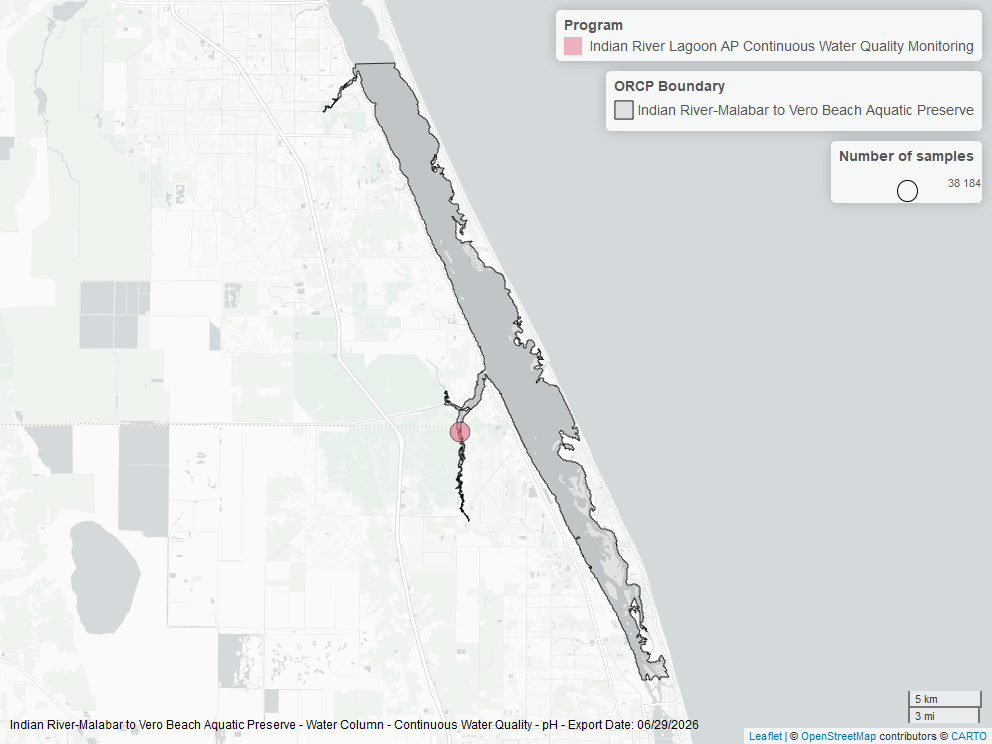

Map showing location of ph continuous water quality sampling locations within the boundaries of *Indian River-Malabar to Vero Beach Aquatic Preserve*. The bubble size on the maps above reflect the amount of data available at each sampling site.

### pH - Discrete

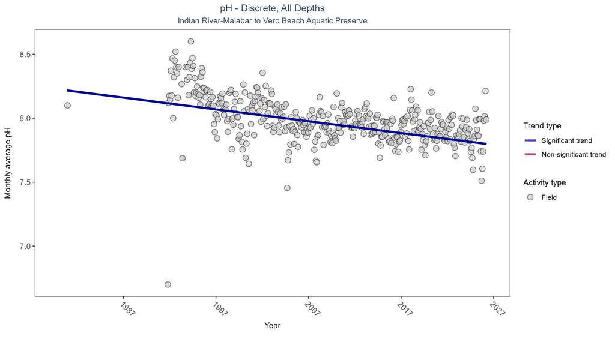

Scatter plot of monthly average pH over time. If the time series included ten or more years of discrete observations, a significant (blue) or non-significant (magenta) trend line is also shown. Only pH values measured in the field (circles) are included in the plot.

Table:

Monthly average pH decreased by 0.01 pH units per year.

| Activity Type | Statistical Trend | Sample Count | Years with Data | Period of Record | Median Result Value | Tau | Sen Intercept | Sen Slope | P |
| --- | --- | --- | --- | --- | --- | --- | --- | --- | --- |
| Field | Decreasing trend | 49382 | 37 | 1980 - 2026 | 8 | -0.4211 | 8.22539 | -0.00923 | 0 |

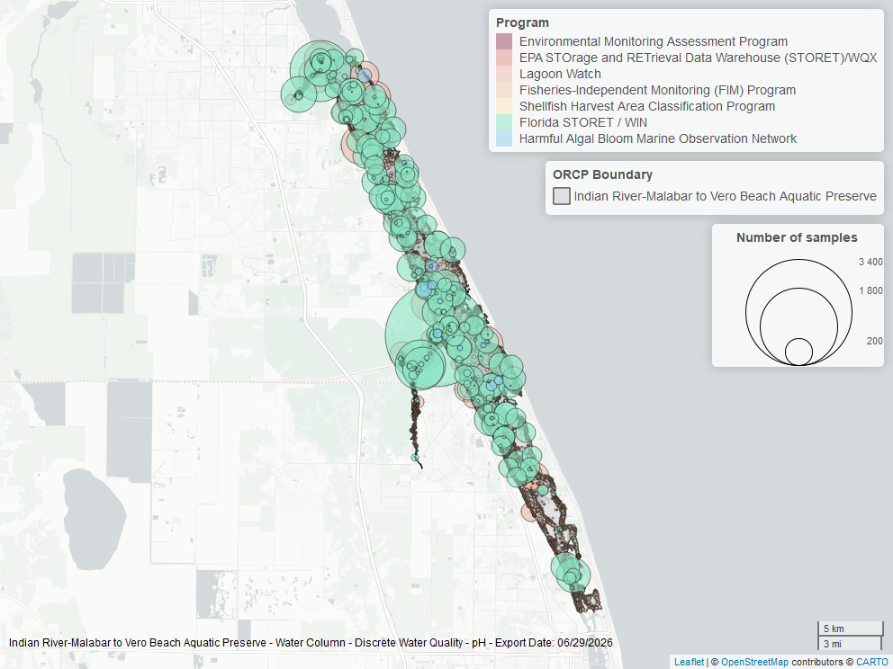

Map showing location of discrete water quality sampling locations within the boundaries of *Indian River-Malabar to Vero Beach Aquatic Preserve*. The bubble size on the maps above reflect the amount of data available at each sampling site.

### Specific Conductivity - Continuous

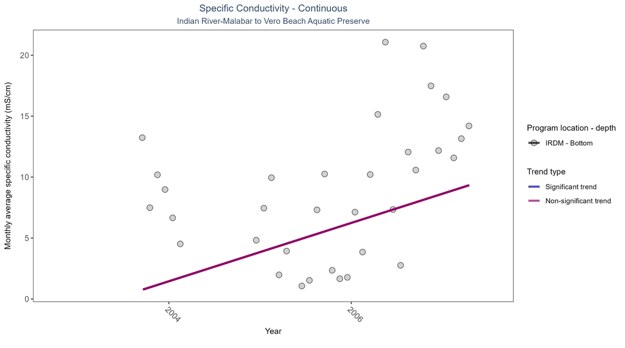

Scatter plot of monthly average specific conductivity over time at continuously monitored program locations. Each location is analyzed separately, with significant (blue) or non-significant (magenta) trend lines shown for time series that included five or more years of observations.

Table:

No detectable change in monthly average specific conductivity was observed at one location.

| Program Location | Statistical Trend | Sample Count | Years with Data | Period of Record | Median Result Value | Tau | Sen Intercept | Sen Slope | P |
| --- | --- | --- | --- | --- | --- | --- | --- | --- | --- |
| IRDM | No detectable trend | 43791 | 5 | 2003 - 2007 | 7.14 | 0.45 | -0.94 | 2.39 | 0.06 |

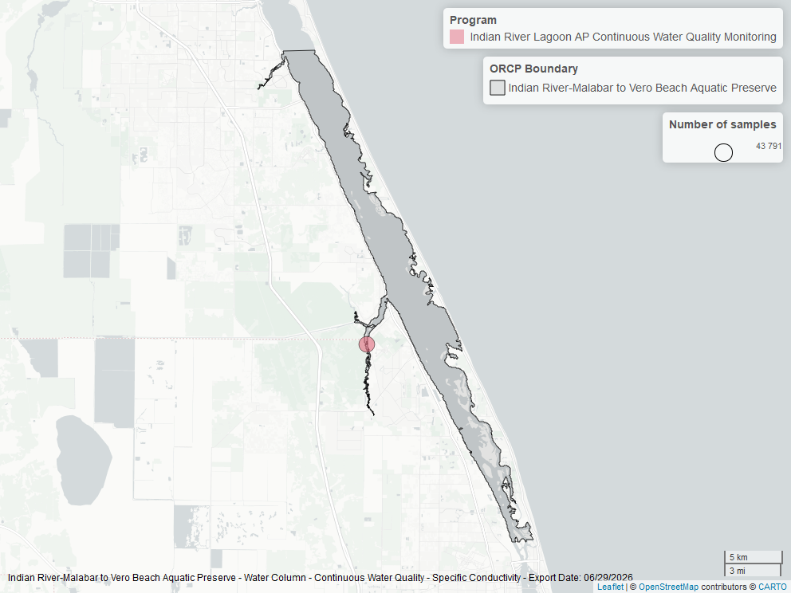

Map showing location of specific conductivity continuous water quality sampling locations within the boundaries of *Indian River-Malabar to Vero Beach Aquatic Preserve*. The bubble size on the maps above reflect the amount of data available at each sampling site.

## Water Clarity

### Turbidity - Continuous

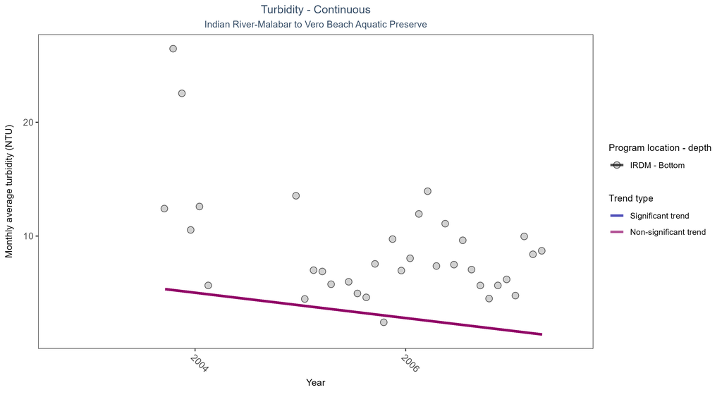

Scatter plot of monthly average turbidity over time at continuously monitored program locations. Each location is analyzed separately, with significant (blue) or non-significant (magenta) trend lines shown for time series that included five or more years of observations.

Table:

No detectable change in monthly average turbidity was observed at one location.

[output not shown]

[figure not shown]

Map showing location of turbidity continuous water quality sampling locations within the boundaries of *Indian River-Malabar to Vero Beach Aquatic Preserve*. The bubble size on the maps above reflect the amount of data available at each sampling site.

### Turbidity - Discrete

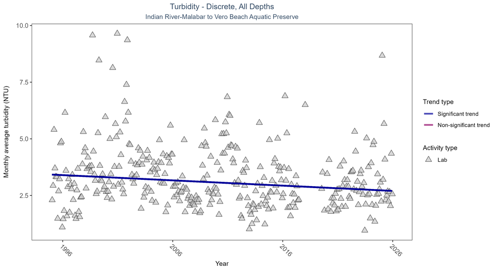

Scatter plot of monthly average turbidity over time. If the time series included ten or more years of discrete observations, a significant (blue) or non-significant (magenta) trend line is also shown. Only turbidity values measured in the laboratory (triangles) are included in the plot.

Table:

Monthly average turbidity decreased by 0.02 NTU per year, indicating an increase in water clarity.

| Activity Type | Statistical Trend | Sample Count | Years with Data | Period of Record | Median Result Value | Tau | Sen Intercept | Sen Slope | P |
| --- | --- | --- | --- | --- | --- | --- | --- | --- | --- |
| Lab | Decreasing trend | 14589 | 31 | 1995 - 2025 | 2.8 | -0.14004 | 3.42196 | -0.02322 | 0.0003 |

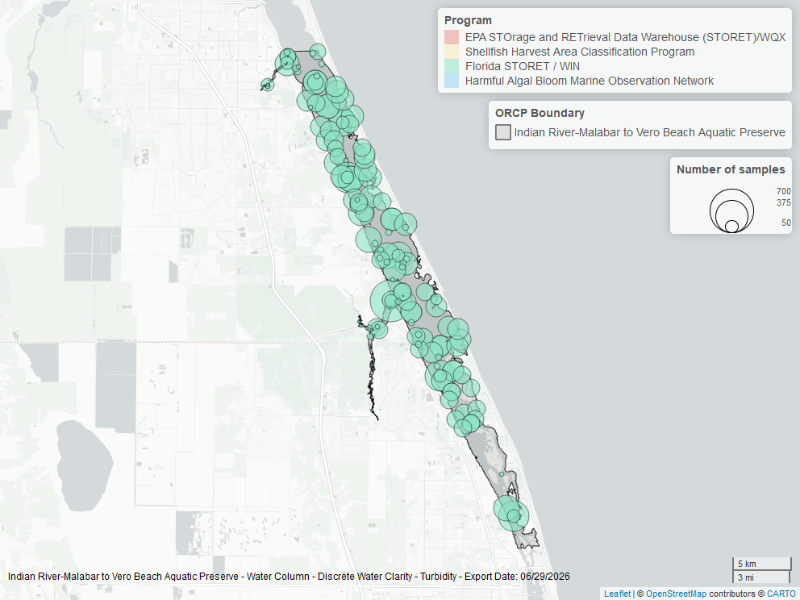

Map showing location of discrete water quality sampling locations within the boundaries of *Indian River-Malabar to Vero Beach Aquatic Preserve*. The bubble size on the maps above reflect the amount of data available at each sampling site.

### Total Suspended Solids - Discrete

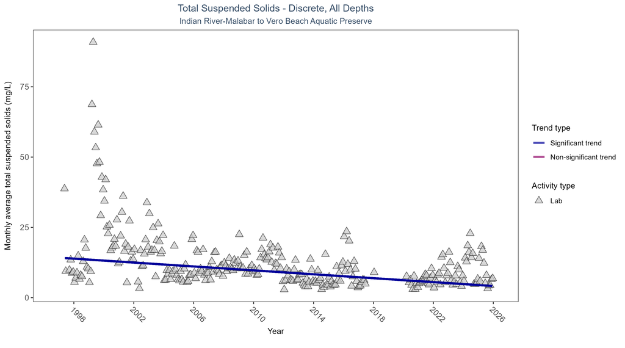

Scatter plot of monthly average total suspended solids (TSS) over time. If the time series included ten or more years of discrete observations, a significant (blue) or non-significant (magenta) trend line is also shown. Only TSS values obtained from laboratory analyses (triangles) are included in the plot.

Table:

Monthly average total suspended solids decreased by 0.35 mg/L per year, indicating an increase in water clarity.

| Activity Type | Statistical Trend | Sample Count | Years with Data | Period of Record | Median Result Value | Tau | Sen Intercept | Sen Slope | P |
| --- | --- | --- | --- | --- | --- | --- | --- | --- | --- |
| Lab | Decreasing trend | 3441 | 28 | 1997 - 2025 | 9 | -0.34919 | 14.23213 | -0.34782 | 0 |

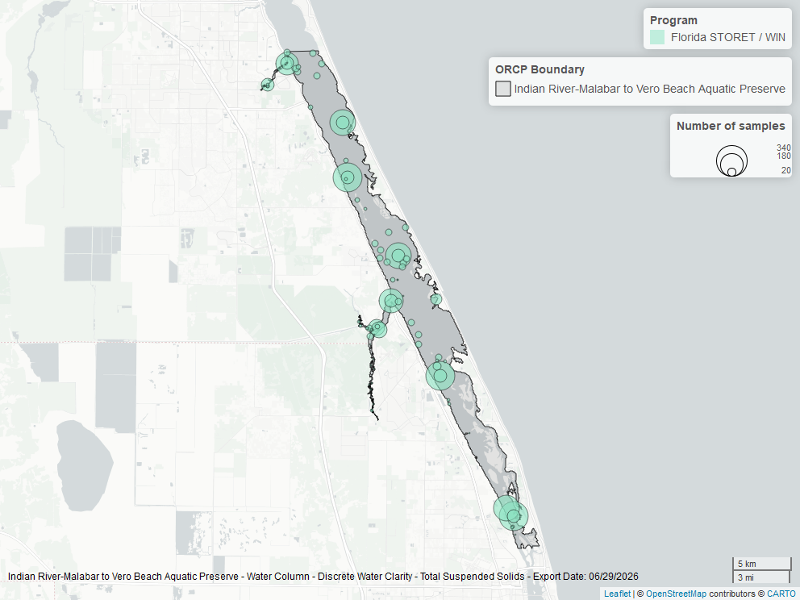

Map showing location of discrete water quality sampling locations within the boundaries of *Indian River-Malabar to Vero Beach Aquatic Preserve*. The bubble size on the maps above reflect the amount of data available at each sampling site.